# UMAP with flow cytometry data files

```r
#Install the pertinent libraries if necessary (some of you will have already done this).
if (!requireNamespace("BiocManager", quietly = TRUE))
    install.packages("BiocManager")
BiocManager::install("flowCore")
#Load the pertinent software libraries.  For more on how to use the flowCore package, see https://www.bioconductor.org/packages/release/bioc/vignettes/flowCore/inst/doc/HowTo-flowCore.pdf.
library(flowCore)

#Install the umap package if necessary.
list.of.packages <- c("umap")
new.packages <- list.of.packages[!(list.of.packages %in% installed.packages()[,"Package"])]
if(length(new.packages)) install.packages(new.packages)
#Load the pertinent software libraries.
library(umap)
```

```r
#Load an FCS file using the flowCore package.
x <- read.FCS("ExampleData/CLL/fff38ca58e3629ad6089579aa3366964a92ffe04-4 CLL 9F 02 N08 001.LMD", transformation = FALSE)
#We are going to use only 20000 data points, just to make the demonstration go faster.
x <- x[1:20000, ]

#Note that the saved listmode (lmd) file is already compensated, so there is no stored compensation matrix to be found.

#List the fluorescence channels used.
markernames(x)
```

```
    FS INT LIN     SS INT LIN    FL1 INT LOG    FL2 INT LOG    FL3 INT LOG    FL4 INT LOG    FL5 INT LOG
  "FS INT LIN"   "SS INT LIN"   "Kappa-FITC"    "Lambda-PE"     "CD38-ECD"   "CD25-PC5.5"    "CD11c-PC7"
   FL6 INT LOG    FL7 INT LOG    FL8 INT LOG    FL9 INT LOG   FL10 INT LOG
   "CD103-APC"  "nix-APCA700" "CD19-APCA750" "CD22-PacBlue"    "CD45-KrOr"
```

Notice that we have “nix-APCA700” as one of the fluorescence channels. This is actually an unused channel, so we would rather not include it in our later UMAP calculation. Let’s convert the data to a standard form (a “dataframe”) that the UMAP algorithm can use, and not have “nix-APCA700” included.

```r
#Copy the data to a regular R dataframe object, which we name "df".
df <- exprs(x)

#"nix-APCA700" was the 9th name in the list, so we are going to drop that column.
df <- subset(df, select = -c(9))

#Show some of the data.
head(df, 3)
```

```
     FS INT LIN SS INT LIN FL1 INT LOG FL2 INT LOG FL3 INT LOG FL4 INT LOG FL5 INT LOG FL6 INT LOG
[1,]        387         78         264         317         203         291         328         219
[2,]        867        284         501         388         229         403         491         307
[3,]        341        116         279         179         547         121         568         219
     FL8 INT LOG FL9 INT LOG FL10 INT LOG
[1,]         491         230          606
[2,]         576         332          687
[3,]           0         122          663
```

Note that we could also ADD columns of data for calculation in the UMAP if desired…

Now we will calculate a UMAP embedding/projection for the flow cytometry data. Here are two websites that have good introductions for running UMAP: For running in R/RStudio: https://cran.r-project.org/web/packages/umap/vignettes/umap.html For running in Python: https://umap-learn.readthedocs.io/en/latest/

First, we will run the UMAP and see what the results look like for NON-scaled data.

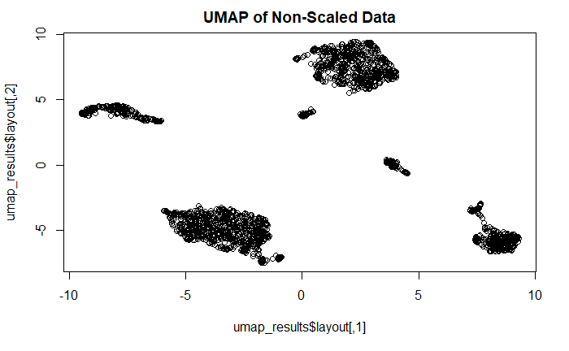

```r
#Set up the parameters we want to use in the UMAP algorithm.
custom.config = umap.defaults
custom.config$random_state = 123

#Let's use a truncated version of the dataframe to speed up the calculation.
df_subset <- df[1:2000, ] #Use the first 2000 data points.

#Run the algorithm on the flow cytometry data dataframe.
umap_results = umap(df_subset, config = custom.config)

#Plot the results.
plot(umap_results$layout, main = "UMAP of Non-Scaled Data")
```

Let’s now scale the data (as we should). We will scale the data by substracting the mean value for each fluorescence channel, then divide by the standard deviation of each channel. This is simply accomplished through R’s “scale” function.

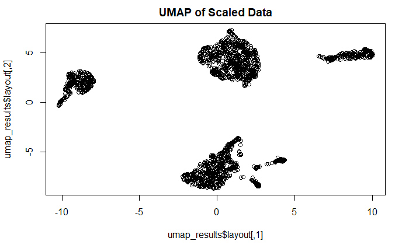

```r
#Scale the data.
df_subset_scaled <- scale(df_subset, center = TRUE, scale = TRUE)

#Run the algorithm on the flow cytometry data dataframe.
umap_results = umap(df_subset_scaled, config = custom.config)

#Plot the results.
plot(umap_results$layout, main = "UMAP of Scaled Data")
```

In the plot, it appears that some of the small clusters clustered a little closer to one of the large clusters. This suggests they are actually fairly similar cell types (the scale of one or more parameters was likely causing an outsized impact on the UMAP algorithm).

Now let’s calculate the UMAP for the full dataframe. This will take longer…

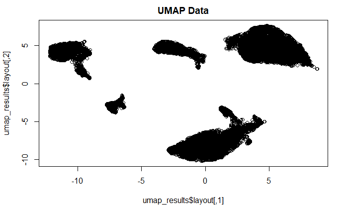

```r
#Scale the data.
df_scaled <- scale(df, center = TRUE, scale = TRUE)

#Run the UMAP algorithm.
umap_results = umap(df_scaled, config = custom.config)

#Plot the results.
plot(umap_results$layout, main = "UMAP Data")
```

Now we want to create a new FCS file that includes the UMAP parameters (as pseudo-fluorescence channels), which we can then open in FlowJo.

```r
#Set up the columns the way we want them to show up in FlowJo.
columns_to_add <- umap_results$layout
colnames(columns_to_add) <- c("UMAP x", "UMAP y")
head(columns_to_add, 3)
```

```
        UMAP x    UMAP y
[1,] -6.531994 -4.016593
[2,] -7.908269 -2.624931
[3,]  8.700891 -1.056143
```

```r
#Now make the new data object for saving as the new flow cytometry data file.
new_x <- x

#Add the UMAP data.
new_x <- fr_append_cols(new_x, columns_to_add)

#Now save it as a new file.
write.FCS(new_x, "ExampleData/CLL FCS file with UMAP channels added.fcs", what="numeric", delimiter = "|", endian="big")
```

```
[1] "ExampleData/CLL FCS file with UMAP channels added.fcs"
```

We can do a quick check to see whether what we wrote is readable and looks appropriate.

```r
#Check whether the file we wrote is readable.
#Load an FCS file using the flowCore package.
y <- read.FCS("ExampleData/CLL FCS file with UMAP channels added.fcs", transformation = FALSE)
df_y <- exprs(y)
head(df_y, 3)
```

```
     FS INT LIN SS INT LIN FL1 INT LOG FL2 INT LOG FL3 INT LOG FL4 INT LOG FL5 INT LOG FL6 INT LOG
[1,]        387         78         264         317         203         291         328         219
[2,]        867        284         501         388         229         403         491         307
[3,]        341        116         279         179         547         121         568         219
     FL7 INT LOG FL8 INT LOG FL9 INT LOG FL10 INT LOG    UMAP x    UMAP y
[1,]         209         491         230          606 -6.531994 -4.016593
[2,]         249         576         332          687 -7.908269 -2.624931
[3,]         176           0         122          663  8.700891 -1.056143
```